# Evaluación_ADI_2025

Victoria Paca

2026-03-05

## 1. INTRODUCCIÓN

En esta evaluación se desarrolla un ejercicio de Analítica de Datos aplicada a la gestión operativa de servicios, utilizando R y RStudio.

La base de datos utilizada corresponde a un Centro de Atención al Cliente (Call Center) de una empresa de servicios de televisión satelital, donde se registran indicadores operativos asociados a la atención de llamadas y la calidad del servicio.

Para cada jornada operativa se registran las siguientes variables:

- **Equipo de atención**: (E1, E2, E3)
- **Turno de operación**: (Mañana, Tarde, Noche)
- Número de **llamadas atendidas** por hora
- **Tiempo promedio** de atención por llamada (minutos)
- Número de **reclamos o incidencias reportadas** por los clientes
- Número de **interrupciones o caídas del sistema** durante el turno
- **Indicador categórico de satisfacción del servicio**: Baja, Media, Alta

El objetivo de la evaluación es aplicar el proceso de analítica de datos es:

- Comprender el problema.
- Preparar y explorar los datos.
- Analizar relaciones entre variables.
- Construir un modelo simple (árbol de decisión).
- Interpretar resultados y proponer conclusiones operativas.

## 2. Creación y Carga del Dataset

### 2.1. Carga de las Librerías

```r
library(dplyr)
```

```r
library(ggplot2)
library(psych)
library(party)
```

### 2.2. Carga y Descripción del Dataset

El archivo data/dataset_callcenter_300.csv es el que contiene la información del servicio, se encuantran registradas las variables críticas del proceso y de calidad.

```r
dataset_callcenter <- read.csv("dataset_callcenter_300.csv")

head(dataset_callcenter)
```

```
##   equipo_atencion turno_operacion llamadas_hora tiempo_promedio_atencion
## 1              E3           Tarde            19                     3.35
## 2              E2           Noche            35                     5.61
## 3              E3           Noche            45                     5.92
## 4              E3           Tarde            41                     4.69
## 5              E1           Tarde            30                     4.42
## 6              E3           Tarde            53                     3.87
##   reclamos_clientes interrupciones_sistema satisfaccion_servicio
## 1                 2                      3                  Baja
## 2                 5                      0                  Baja
## 3                 7                      0                  Baja
## 4                 2                      2                 Media
## 5                 6                      0                  Baja
## 6                 6                      2                  Baja
```

```r
str(dataset_callcenter)
```

```
## 'data.frame':    300 obs. of  7 variables:
##  $ equipo_atencion         : chr  "E3" "E2" "E3" "E3" ...
##  $ turno_operacion         : chr  "Tarde" "Noche" "Noche" "Tarde" ...
##  $ llamadas_hora           : int  19 35 45 41 30 53 32 46 39 34 ...
##  $ tiempo_promedio_atencion: num  3.35 5.61 5.92 4.69 4.42 3.87 4.69 3.93 5.45 5.84 ...
##  $ reclamos_clientes       : int  2 5 7 2 6 6 11 5 2 3 ...
##  $ interrupciones_sistema  : int  3 0 0 2 0 2 4 3 3 2 ...
##  $ satisfaccion_servicio   : chr  "Baja" "Baja" "Baja" "Media" ...
```

```r
dim(dataset_callcenter)
```

```
## [1] 300   7
```

```r
names(dataset_callcenter)
```

```
## [1] "equipo_atencion"          "turno_operacion"
## [3] "llamadas_hora"            "tiempo_promedio_atencion"
## [5] "reclamos_clientes"        "interrupciones_sistema"
## [7] "satisfaccion_servicio"
```

```r
summary(dataset_callcenter)
```

```
##  equipo_atencion    turno_operacion    llamadas_hora   tiempo_promedio_atencion
##  Length:300         Length:300         Min.   :19.00   Min.   :2.100
##  Class :character   Class :character   1st Qu.:36.00   1st Qu.:4.900
##  Mode  :character   Mode  :character   Median :42.00   Median :5.690
##                                        Mean   :41.57   Mean   :5.699
##                                        3rd Qu.:47.00   3rd Qu.:6.480
##                                        Max.   :63.00   Max.   :9.170
##  reclamos_clientes interrupciones_sistema satisfaccion_servicio
##  Min.   : 0.000    Min.   :0.00           Length:300
##  1st Qu.: 3.000    1st Qu.:1.00           Class :character
##  Median : 4.000    Median :2.00           Mode  :character
##  Mean   : 4.013    Mean   :2.11
##  3rd Qu.: 5.000    3rd Qu.:3.00
##  Max.   :11.000    Max.   :7.00
```

## 3. Análisis Exploratorio de Datos

El análisis exploratorio de Datos constituye una etapa fundamental del proceso, cuyo objetivo es comprender la estructura, distribución y características principales del conjunto de datos.

```r
dataset_callcenter$equipo_atencion <- as.factor(dataset_callcenter$equipo_atencion)
dataset_callcenter$turno_operacion <- as.factor(dataset_callcenter$turno_operacion)
dataset_callcenter$satisfaccion_servicio <- as.factor(dataset_callcenter$satisfaccion_servicio)
```

### 3.1. Exploración de Datos

Se realiza un análisis exploratorio del dataset del centro de atención al cliente para identificar patrones iniciales, posibles relaciones entre variables y comportamientos que puedan influir en el nivel de satisfacción del servicio. Esta etapa permitirá orientar el análisis posterior y la construcción del modelo de decisión.

#### Estadísticos Descriptivos Univariados

```r
describe(dataset_callcenter)
```

```
##                          vars   n  mean   sd median trimmed  mad  min   max
## equipo_atencion*            1 300  2.04 0.81   2.00    2.05 1.48  1.0  3.00
## turno_operacion*            2 300  2.00 0.82   2.00    2.00 1.48  1.0  3.00
## llamadas_hora               3 300 41.57 7.87  42.00   41.51 7.41 19.0 63.00
## tiempo_promedio_atencion    4 300  5.70 1.22   5.69    5.69 1.17  2.1  9.17
## reclamos_clientes           5 300  4.01 2.03   4.00    3.96 1.48  0.0 11.00
## interrupciones_sistema      6 300  2.11 1.45   2.00    2.05 1.48  0.0  7.00
## satisfaccion_servicio*      7 300  2.19 0.54   2.00    2.20 0.00  1.0  3.00
##                          range  skew kurtosis   se
## equipo_atencion*          2.00 -0.07    -1.48 0.05
## turno_operacion*          2.00  0.01    -1.50 0.05
## llamadas_hora            44.00  0.04     0.07 0.45
## tiempo_promedio_atencion  7.07  0.05     0.32 0.07
## reclamos_clientes        11.00  0.37     0.50 0.12
## interrupciones_sistema    7.00  0.52    -0.01 0.08
## satisfaccion_servicio*    2.00  0.11    -0.06 0.03
```

#### Distribución del Nivel de Calidad

```r
table(dataset_callcenter$satisfaccion_servicio)
```

```
##
##  Alta  Baja Media
##    21   202    77
```

```r
prop.table(table(dataset_callcenter$satisfaccion_servicio))
```

```
##
##      Alta      Baja     Media
## 0.0700000 0.6733333 0.2566667
```

### 3.2. Histográmas

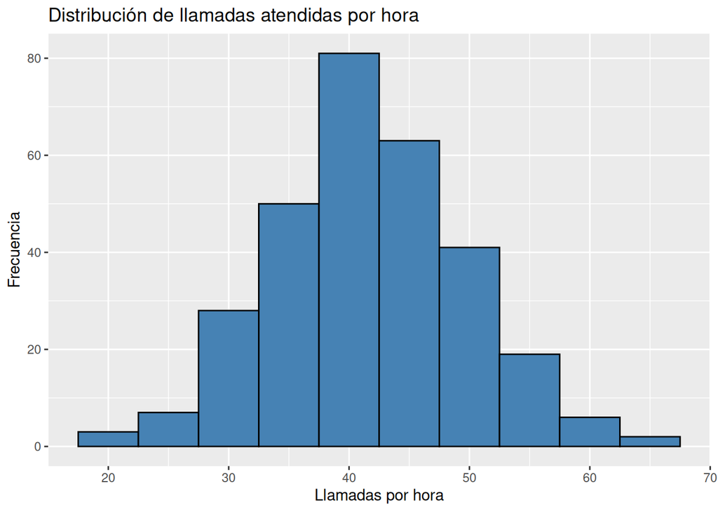

```r
ggplot(dataset_callcenter, aes(x = llamadas_hora)) +
  geom_histogram(binwidth = 5, fill = "steelblue", color = "black") +
  labs(title = "Distribución de llamadas atendidas por hora",
       x = "Llamadas por hora",
       y = "Frecuencia")
```

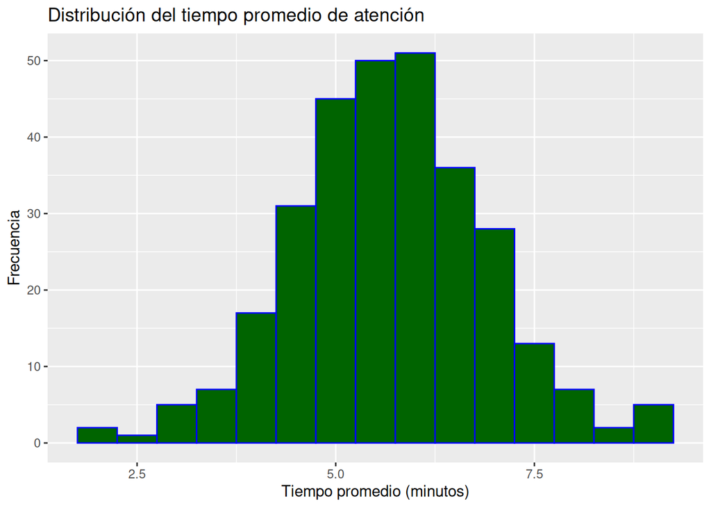

```r
ggplot(dataset_callcenter, aes(x = tiempo_promedio_atencion)) +
  geom_histogram(binwidth = 0.5, fill = "darkgreen", color = "blue") +
  labs(title = "Distribución del tiempo promedio de atención",
       x = "Tiempo promedio (minutos)",
       y = "Frecuencia")
```

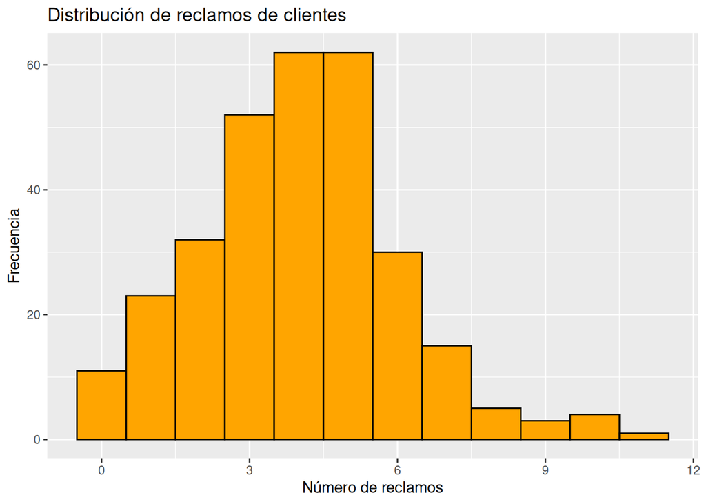

```r
ggplot(dataset_callcenter, aes(x = reclamos_clientes)) +
  geom_histogram(binwidth = 1, fill = "orange", color = "black") +
  labs(title = "Distribución de reclamos de clientes",
       x = "Número de reclamos",
       y = "Frecuencia")
```

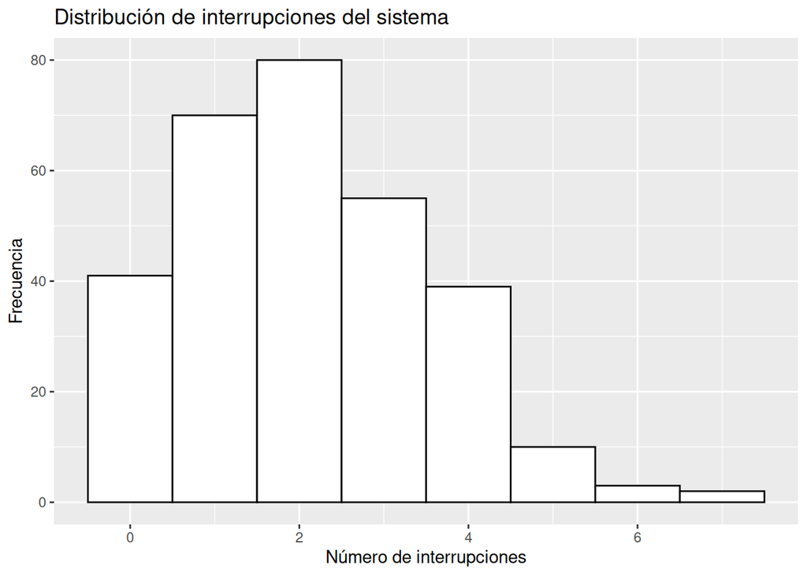

```r
ggplot(dataset_callcenter, aes(x = interrupciones_sistema)) +
  geom_histogram(binwidth = 1, fill = "white", color = "black") +
  labs(title = "Distribución de interrupciones del sistema",
       x = "Número de interrupciones",
       y = "Frecuencia")
```

### 3.3. Boxplots por Variable

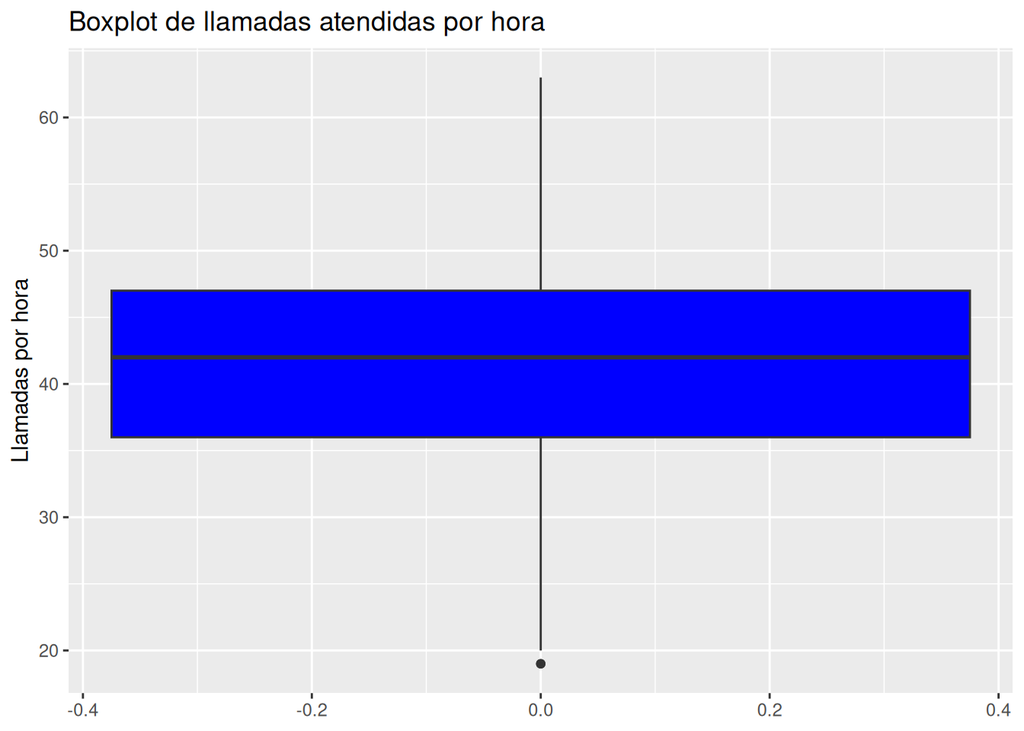

```r
ggplot(dataset_callcenter, aes(y = llamadas_hora)) +
  geom_boxplot(fill = "blue") +
  labs(title = "Boxplot de llamadas atendidas por hora", y = "Llamadas por hora")
```

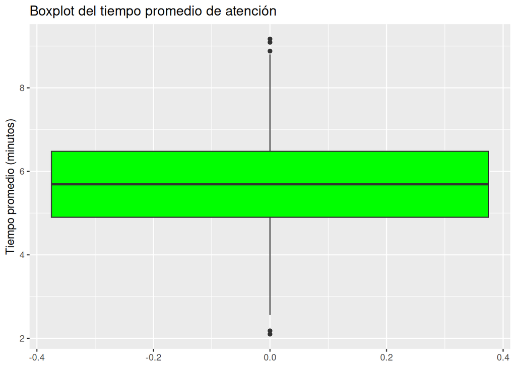

```r
ggplot(dataset_callcenter, aes(y = tiempo_promedio_atencion)) +
  geom_boxplot(fill = "green") +
  labs(title = "Boxplot del tiempo promedio de atención",
       y = "Tiempo promedio (minutos)")
```

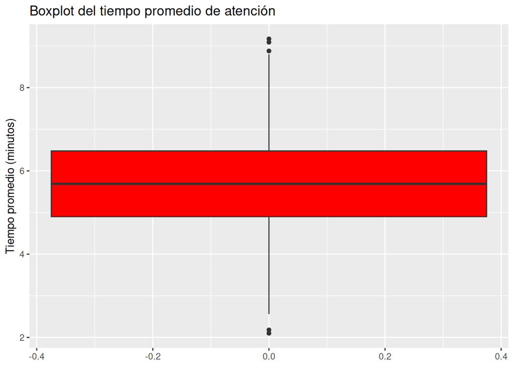

```r
ggplot(dataset_callcenter, aes(y = tiempo_promedio_atencion)) +
  geom_boxplot(fill = "red") +
  labs(title = "Boxplot del tiempo promedio de atención",
       y = "Tiempo promedio (minutos)")
```

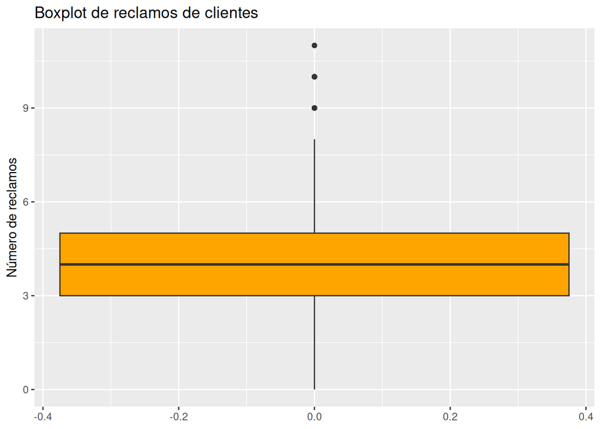

```r
ggplot(dataset_callcenter, aes(y = reclamos_clientes)) +
  geom_boxplot(fill = "orange") +
  labs(title = "Boxplot de reclamos de clientes",
       y = "Número de reclamos")
```

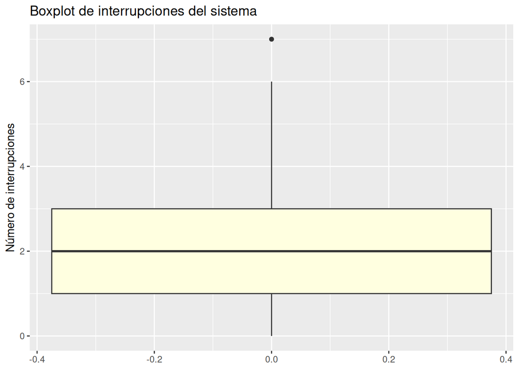

```r
ggplot(dataset_callcenter, aes(y = interrupciones_sistema)) +
  geom_boxplot(fill = "lightyellow") +
  labs(title = "Boxplot de interrupciones del sistema",
       y = "Número de interrupciones")
```

### 3.4. Calidad por Turno

```r
tabla_cal_turno <- table(dataset_callcenter$turno, dataset_callcenter$satisfaccion_servicio)
tabla_cal_turno
```

```
##
##          Alta Baja Media
##   Mañana   12   53    35
##   Noche     3   84    14
##   Tarde     6   65    28
```

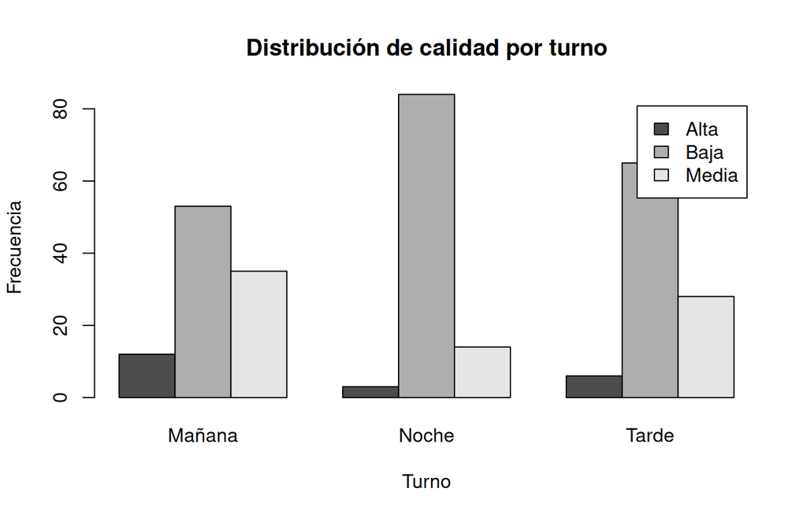

```r
barplot(t(tabla_cal_turno),
        beside = TRUE,
        legend = TRUE,
        main   = "Distribución de calidad por turno",
        xlab   = "Turno",
        ylab   = "Frecuencia")
```

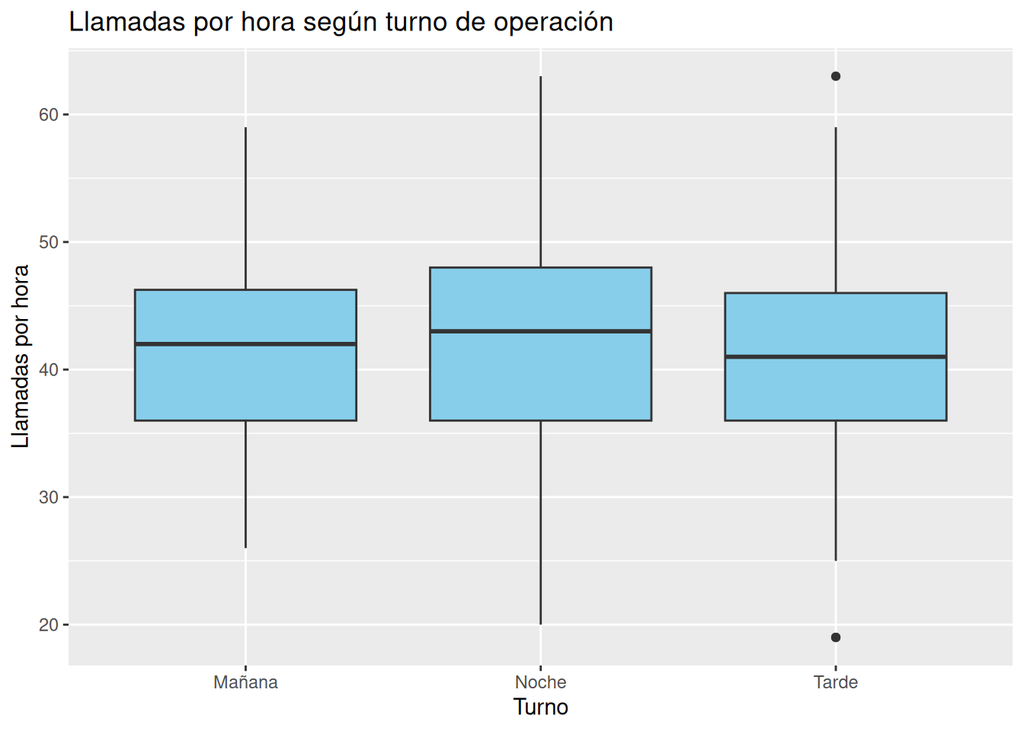

```r
ggplot(dataset_callcenter, aes(x = turno_operacion, y = llamadas_hora)) +
  geom_boxplot(fill = "skyblue") +
  labs(title = "Llamadas por hora según turno de operación",
       x = "Turno",
       y = "Llamadas por hora")
```

## 4. Análisis Multivariado

```r
vars_numericas <- dataset_callcenter %>%
  dplyr::select(llamadas_hora, tiempo_promedio_atencion, reclamos_clientes, interrupciones_sistema)
```

### 4.1. Matriz de Correlación

```r
cor(vars_numericas)
```

```
##                          llamadas_hora tiempo_promedio_atencion
## llamadas_hora              1.000000000             -0.059048654
## tiempo_promedio_atencion  -0.059048654              1.000000000
## reclamos_clientes          0.001616432              0.035895027
## interrupciones_sistema    -0.072047905             -0.002862391
##                          reclamos_clientes interrupciones_sistema
## llamadas_hora                  0.001616432           -0.072047905
## tiempo_promedio_atencion       0.035895027           -0.002862391
## reclamos_clientes              1.000000000            0.027937375
## interrupciones_sistema         0.027937375            1.000000000
```

### 4.2. Gráficos de dispersión

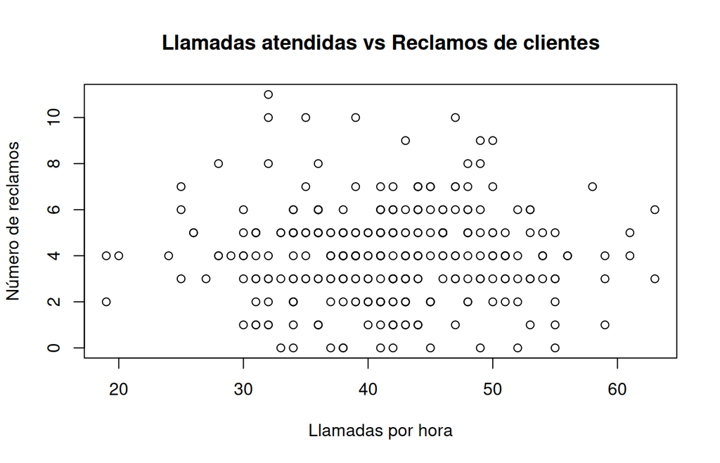

```r
plot(dataset_callcenter$llamadas_hora, dataset_callcenter$reclamos_clientes,
     xlab = "Llamadas por hora",
     ylab = "Número de reclamos",
     main = "Llamadas atendidas vs Reclamos de clientes")
```

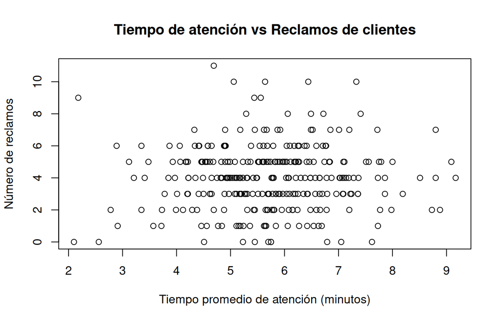

```r
plot(dataset_callcenter$tiempo_promedio_atencion, dataset_callcenter$reclamos_clientes,
     xlab = "Tiempo promedio de atención (minutos)",
     ylab = "Número de reclamos",
     main = "Tiempo de atención vs Reclamos de clientes")
```

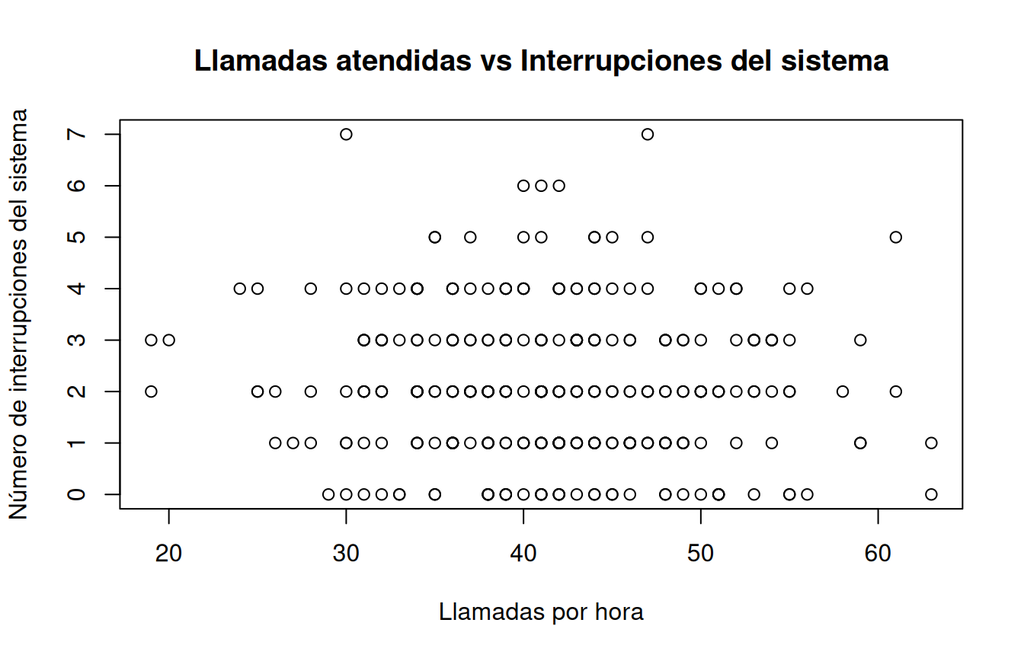

```r
plot(dataset_callcenter$llamadas_hora, dataset_callcenter$interrupciones_sistema,
     xlab = "Llamadas por hora",
     ylab = "Número de interrupciones del sistema",
     main = "Llamadas atendidas vs Interrupciones del sistema")
```

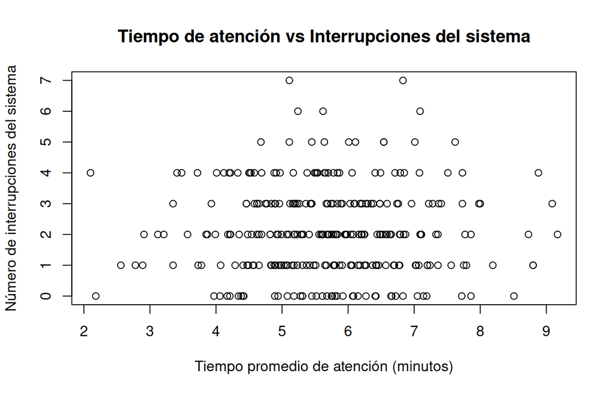

```r
plot(dataset_callcenter$tiempo_promedio_atencion, dataset_callcenter$interrupciones_sistema,
     xlab = "Tiempo promedio de atención (minutos)",
     ylab = "Número de interrupciones del sistema",
     main = "Tiempo de atención vs Interrupciones del sistema")
```

## 5. Modelo de analítica de datos (Árbol de decisión)

Se construye un modelo de árbol de decisión con el objetivo de identificar qué variables operativas influyen en el nivel de satisfacción del servicio. Este modelo permite generar reglas de decisión que facilitan la interpretación de patrones y la toma de decisiones operativas basada en datos.

### 5.1. Conjunto de entrenamiento y prueba

```r
set.seed(2025)

ind <- sample(2,
              size    = nrow(dataset_callcenter),
              replace = TRUE,
              prob    = c(0.7, 0.3))

trainData <- dataset_callcenter[ind == 1, ]
testData  <- dataset_callcenter[ind == 2, ]

nrow(trainData); nrow(testData)
```

```
## [1] 200
```

```
## [1] 100
```

### 5.2. Entrenamiento

```r
formula_arbol <- satisfaccion_servicio ~ llamadas_hora + tiempo_promedio_atencion +
                                        reclamos_clientes + interrupciones_sistema +
                                        equipo_atencion + turno_operacion

arbol_satisfaccion <- ctree(formula_arbol, data = trainData)

arbol_satisfaccion
```

```
##
##   Conditional inference tree with 9 terminal nodes
##
## Response:  satisfaccion_servicio
## Inputs:  llamadas_hora, tiempo_promedio_atencion, reclamos_clientes, interrupciones_sistema, equipo_atencion, turno_operacion
## Number of observations:  200
##
## 1) reclamos_clientes <= 2; criterion = 1, statistic = 45.27
##   2) interrupciones_sistema <= 2; criterion = 1, statistic = 22.956
##     3)*  weights = 24
##   2) interrupciones_sistema > 2
##     4)*  weights = 17
## 1) reclamos_clientes > 2
##   5) interrupciones_sistema <= 1; criterion = 1, statistic = 34.67
##     6) reclamos_clientes <= 4; criterion = 0.993, statistic = 16.621
##       7) tiempo_promedio_atencion <= 6.25; criterion = 0.972, statistic = 11.941
##         8)*  weights = 17
##       7) tiempo_promedio_atencion > 6.25
##         9)*  weights = 10
##     6) reclamos_clientes > 4
##       10) llamadas_hora <= 45; criterion = 0.994, statistic = 10.904
##         11)*  weights = 21
##       10) llamadas_hora > 45
##         12)*  weights = 8
##   5) interrupciones_sistema > 1
##     13) turno_operacion == {Noche, Tarde}; criterion = 0.973, statistic = 10.802
##       14)*  weights = 67
##     13) turno_operacion == {Mañana}
##       15) tiempo_promedio_atencion <= 5.19; criterion = 0.98, statistic = 8.64
##         16)*  weights = 8
##       15) tiempo_promedio_atencion > 5.19
##         17)*  weights = 28
```

### 5.3. Evaluación del Entrenamiento

```r
pred_train <- predict(arbol_satisfaccion)
tabla_train <- table(Predicho = pred_train, Real = trainData$satisfaccion_servicio)
tabla_train
```

```
##         Real
## Predicho Alta Baja Media
##    Alta     0    0     0
##    Baja     1  129    13
##    Media   14    7    36
```

```r
acc_train <- sum(diag(tabla_train)) / sum(tabla_train)
acc_train
```

```
## [1] 0.825
```

### 5.4. Evaluación en datos de prueba

```r
pred_test <- predict(arbol_satisfaccion, newdata = testData)
tabla_test <- table(Predicho = pred_test, Real = testData$satisfaccion_servicio)
tabla_test
```

```
##         Real
## Predicho Alta Baja Media
##    Alta     0    0     0
##    Baja     0   57     8
##    Media    6    9    20
```

```r
acc_test <- sum(diag(tabla_test)) / sum(tabla_test)
acc_test
```

```
## [1] 0.77
```